# Analysing timeliness of transmission in the German surveillance system

Jakob Schumacher

Januar 2016

# About this document

This document calculates and produces a manuscript to analyze the transmission delay in the German Surveillance System

- Title of the publication: Timeliness in the German surveillance system for infectious diseases: Amendment of the infection protection act in 2013 decreased local transmission time to 1 day.
- Authors of the publication: Jakob Schumacher, Michaela Diercke, Maelle Salmon, Irina Czogiel, Claus Herrmann, Andreas Gilsdorf

### Loading packages

```r
if (!require("dplyr")) install.packages('dplyr', repos="http://cran.rstudio.com/"); require("dplyr") # Reshaping data
if (!require("tidyr")) install.packages('tidyr', repos="http://cran.rstudio.com/"); require("tidyr") # Reshaping data
if (!require("ggplot2")) install.packages('ggplot2', repos="http://cran.rstudio.com/"); require("ggplot2") # Graphics
if (!require("scales")) install.packages('scales', repos="http://cran.rstudio.com/"); require("scales") # Graphics
if (!require("grid")) install.packages('grid', repos="http://cran.rstudio.com/"); require("grid")
if (!require("knitr")) install.packages('knitr', repos="http://cran.rstudio.com/"); require("knitr")
if (!require("gridExtra")) install.packages('gridExtra', repos="http://cran.rstudio.com/"); require("gridExtra")
if (!require("timeDate")) install.packages('timeDate', repos="http://cran.rstudio.com/"); require("timeDate")
if (!require("svglite")) install.packages('svglite', repos="http://cran.rstudio.com/"); require("svglite")
if (!require("DT")) install.packages('DT'); require("DT") # HTML Output
```

### Setting Options and small functions

```r
options(dplyr.print_max = 1000) # Dplyr should pirnt out more lines
knitr::opts_chunk$set(message=FALSE, warning=FALSE, results="asis") # Knitr chunk options

# Helper functions
select <- dplyr::select # Collision with MASS package
"%nin%" <- function (x, table) match(x, table, nomatch = 0L) == 0L
```

# Getting data

### Querying database

```r
# if (!require("RODBC")) install.packages('RODBC'); require("RODBC")
# # Creating a function for the query
# getData <- function () {
#   # hier wird definiert, wie man sich mit der Datenbank verbindet
#   connection <- odbcDriverConnect("driver={SQL Server};server=sesql10;
#                                   UID=SQL_SurvNet3_User;PWD=SurvNet3;
#                                   Database=SurvNet3RKI2;",
#                                   readOnlyOptimize=TRUE)
#
#   query <- "
#   SELECT
#   CAST(DISEASE71.[OnsetOfDisease] AS DATE) AS [Erkrankungsbeginn]
#   ,CAST(NA1.[DiagnosedAt] AS DATE) AS [ArztDiagnoseAm]
#   ,CAST(NA1.[NotifiedAt] AS DATE) AS [ArztMeldungImGA]
#   ,CAST(NL1.[DiagnosedAt] AS DATE) AS [LaborDiagnoseAm]
#   ,CAST(NL1.[NotifiedAt] AS DATE) AS [LaborMeldungImGA]
#   ,CAST(N3.[DiagnosedAt] AS DATE) AS [EigeneErmittlungDiagnoseAm]
#   ,CAST(N3.[NotifiedAt] AS DATE) AS [EigeneErmittlungMeldungImGA]
#   ,CAST(N4.[DiagnosedAt] AS DATE) AS [GemeinschaftP8DiagnoseAm]
#   ,CAST(N4.[NotifiedAt] AS DATE) AS [GemeinschaftP8MeldungImGA]
#   ,CAST(N5.[DiagnosedAt] AS DATE) AS [WeiterleitungAnderesGADiagnoseAm]
#   ,CAST(N5.[NotifiedAt] AS DATE) AS [WeiterleitungAnderesGAMeldungImGA]
#   ,CAST(N6.[DiagnosedAt] AS DATE) AS [GemeinschaftP34DiagnoseAm]
#   ,CAST(N6.[NotifiedAt] AS DATE) AS [GemeinschaftP34MeldungImGA]
#   ,CAST(N99.[DiagnosedAt] AS DATE) AS [AndereDiagnoseAm]
#   ,CAST(N99.[NotifiedAt] AS DATE) AS [AndereMeldungImGA]
#   ,CAST(Nx.[DiagnosedAt] AS DATE) AS [UnbekannteMeldeArtDiagnoseAm]
#   ,CAST(Nx.[NotifiedAt] AS DATE) AS [UnbekannteMeldeArtImGA]
#   ,CAST(RT1.[TrackedAt] AS DATE) AS [ErstelltGA]
#   ,CAST(DISEASE71.[ReportingDate] AS DATE) AS [Meldedatum]
#   ,CAST(RT2.[TrackedAt] AS DATE) AS [ExportGA]
#   ,CAST(RT3.[TrackedAt] AS DATE) AS [ImportLS]
#   ,CAST(RT4.[TrackedAt] AS DATE) AS [ExportLS]
#   ,CAST(RT5.[TrackedAt] AS DATE) AS [ImportRKI]
#
#   -- Disease --
#   ,M.[GuiText] AS [Disease]
#   ,MD.[SpecimenName]
#   ,DisPat.[Pathogen]
#   ,[Meta].[ParseCatalogeItem](10001, DISEASE71.[CaseDefCategoryComputed]) AS [CaseDefCategoryComputed]
#
#   -- Software --
#   ,SoftwareGA.[SN2SN3] AS 'SoftwareSN2SN3GA'
#   ,SoftwareGA.[SW] AS 'SoftwareGruppeGA'
#
#   -- Place --
#   ,(SELECT I.ItemName FROM Meta.Catalogue2Item AS C2I INNER JOIN Meta.Item AS I ON C2I.IdItem = I.IdItem WHERE C2I.IdCatalogue = 1012 AND I.IdIndex = DISEASE71.[ReportingState])  AS [ReportingStateName]
#   ,(SELECT ISNULL(TS.[Name1],'')+ ISNULL('-'+[Name2],'') FROM [Meta].[TransmittingSite] TS WHERE TS.[CodeSite] = V.[CodeRecordOwner]) AS [MeldendesGA]
#
#   -- Person --
#   ,(SELECT I.ItemName FROM Meta.Catalogue2Item AS C2I INNER JOIN Meta.Item AS I ON C2I.IdItem = I.IdItem WHERE C2I.IdCatalogue = 3002 AND I.IdIndex = DISEASE71.[Sex])  AS [Geschlecht]
#   ,DISEASE71.[AgeComputed] AS [Alter]
#
#   -- Variables --
#   ,V.[VersionNo]
#   ,Vacc.[StatusVaccination] AS 'ImpfungStatus'
#   ,(SELECT I.ItemName FROM Meta.Catalogue2Item AS C2I INNER JOIN Meta.Item AS I ON C2I.IdItem = I.IdItem WHERE C2I.IdCatalogue = 1009 AND I.IdIndex = DISEASE71.[StatusPatientSetting]) AS 'Status_33_36_42'
#
#
#   -- Time variables --
#   ,RD.[Week] AS 'Meldewoche'
#   ,RD.[Month] AS 'Meldemonat'
#   ,RD.[Quarter] AS 'Meldequartal'
#   ,RD.[WeekYear] AS 'Meldejahr'
#
#   FROM
#   [Data].[Version] AS V
#   INNER JOIN [Data].[Disease71] AS DISEASE71 ON V.[IdVersion] = DISEASE71.[IdVersion]
#   INNER JOIN Meta.DayTable RD ON RD.[IdDaySQL] = CAST(CAST(DISEASE71.[ReportingDate] AS FLOAT) AS INT)
#   INNER JOIN Meta.[Type] M ON V.IdType = M.IdType
#   INNER JOIN Meta.[Disease] MD ON V.IdType = MD.IdType AND V.IdSchema = MD.IdSchema
#   OUTER APPLY [Data].[ExpandWithVaccination] (V.[IdVersion]) Vacc
#   OUTER APPLY [Data].[ExpandWithDiseasePathogen](V.[IdVersion]) DisPat
#
#
#   OUTER APPLY (SELECT [IdVersion], MIN([NotifiedAt]) AS [NotifiedAt], MIN([DiagnosedAt]) AS [DiagnosedAt] FROM [Data].[Disease71Notification] N WHERE V.[IdVersion] = N.[IdVersion] AND [NotificationType] = 1 GROUP BY [IdVersion]) NA1
#   OUTER APPLY (SELECT [IdVersion], MIN([NotifiedAt]) AS [NotifiedAt], MIN([DiagnosedAt]) AS [DiagnosedAt] FROM [Data].[Disease71Notification] N WHERE V.[IdVersion] = N.[IdVersion] AND [NotificationType] = 2 GROUP BY [IdVersion]) NL1
#   OUTER APPLY (SELECT [IdVersion], MIN([NotifiedAt]) AS [NotifiedAt], MIN([DiagnosedAt]) AS [DiagnosedAt] FROM [Data].[Disease71Notification] N WHERE V.[IdVersion] = N.[IdVersion] AND [NotificationType] = 3 GROUP BY [IdVersion]) N3
#   OUTER APPLY (SELECT [IdVersion], MIN([NotifiedAt]) AS [NotifiedAt], MIN([DiagnosedAt]) AS [DiagnosedAt] FROM [Data].[Disease71Notification] N WHERE V.[IdVersion] = N.[IdVersion] AND [NotificationType] = 4 GROUP BY [IdVersion]) N4
#   OUTER APPLY (SELECT [IdVersion], MIN([NotifiedAt]) AS [NotifiedAt], MIN([DiagnosedAt]) AS [DiagnosedAt] FROM [Data].[Disease71Notification] N WHERE V.[IdVersion] = N.[IdVersion] AND [NotificationType] = 5 GROUP BY [IdVersion]) N5
#   OUTER APPLY (SELECT [IdVersion], MIN([NotifiedAt]) AS [NotifiedAt], MIN([DiagnosedAt]) AS [DiagnosedAt] FROM [Data].[Disease71Notification] N WHERE V.[IdVersion] = N.[IdVersion] AND [NotificationType] = 6 GROUP BY [IdVersion]) N6
#   OUTER APPLY (SELECT [IdVersion], MIN([NotifiedAt]) AS [NotifiedAt], MIN([DiagnosedAt]) AS [DiagnosedAt] FROM [Data].[Disease71Notification] N WHERE V.[IdVersion] = N.[IdVersion] AND [NotificationType] = 999999 GROUP BY [IdVersion]) N99
#   OUTER APPLY (SELECT [IdVersion], MIN([NotifiedAt]) AS [NotifiedAt], MIN([DiagnosedAt]) AS [DiagnosedAt] FROM [Data].[Disease71Notification] N WHERE V.[IdVersion] = N.[IdVersion] AND [NotificationType] IN (0,-1) GROUP BY [IdVersion]) Nx
#   OUTER APPLY (SELECT [IdRecord], MIN([TrackedAt]) AS [TrackedAt] FROM [Data].[RecordTrack] RT WHERE V.[IdRecord] = RT.[IdRecord] AND [Action] = 1 GROUP BY [IdRecord]) RT1
#   OUTER APPLY (SELECT [IdRecord], MIN([TrackedAt]) AS [TrackedAt] FROM [Data].[RecordTrack] RT WHERE V.[IdRecord] = RT.[IdRecord] AND [Action] = 2 AND [CodeSite] LIKE '1.__._%' GROUP BY [IdRecord]) RT2
#   OUTER APPLY (SELECT [IdRecord], MIN([TrackedAt]) AS [TrackedAt] FROM [Data].[RecordTrack] RT WHERE V.[IdRecord] = RT.[IdRecord] AND [Action] = 3 AND [CodeSite] LIKE '1.__.' GROUP BY [IdRecord]) RT3
#   OUTER APPLY (SELECT [IdRecord], MIN([TrackedAt]) AS [TrackedAt] FROM [Data].[RecordTrack] RT WHERE V.[IdRecord] = RT.[IdRecord] AND [Action] = 2 AND [CodeSite] LIKE '1.__.' GROUP BY [IdRecord]) RT4
#   OUTER APPLY (SELECT [IdRecord], MIN([TrackedAt]) AS [TrackedAt] FROM [Data].[RecordTrack] RT WHERE V.[IdRecord] = RT.[IdRecord] AND [Action] = 3 AND [CodeSite] = '1.' GROUP BY [IdRecord]) RT5
#
#   OUTER APPLY [Data].[ExpandWithSoftware] (V.[IdRecord]) SoftwareGA WHERE
#   V.[IdRecordType] = 1    -- nur Faelle
#   AND V.[IsCurrent] = 1   -- nur aktuelle Version des Falls
#   AND V.[IsActive] = 1   -- nur aktive Faelle (nicht geloescht oder verworfen)
#   AND DISEASE71.[ReportingDate] BETWEEN '2012-03-29' AND '2014-03-28' "
#   data <- sqlQuery(connection, query)
#   close(connection)
#   data
# }
#
# # Executing the function
# #data <- getData()
#
# # Saving the dataset
# #save(data, file="rawData.RData")
```

### Loading data

```r
load(file="../Data/rawData.RData")

# Other data
DiseaseDF <- read.table(file="../Data/Diseases.csv", header=TRUE, sep=";", quote="", row.names = NULL, colClasses = "character")
FederalstatesDF <- read.table("../Data/FederalStates.csv", header=TRUE, sep=";", row.names = NULL, colClasses = "character")
Holidays <- read.table("../Data/Holidays.csv", header=FALSE, sep=";", row.names = NULL, colClasses = "character") %>% .[["V1"]]
WorkingDays <- sum(isBizday(timeDate(seq(as.Date("2012/03/29"), as.Date("2014/03/28"), "days")), holidays=Holidays, wday=1:5))

# Initialize variable for protocol
protocol <- list(TotalNumberRetrieved=nrow(data))
```

# Cleaning data

### Changing class and small changes

```r
data <- data %>%
  mutate_each(funs(as.Date(., format = "%Y-%m-%d")), 1:23) %>%
  mutate_each(funs(as.character(.)), 24:32,35:36) %>%
  mutate_each(funs(as.numeric(.)), 33:34, 37:40) %>%
  mutate_each(funs(replace(., .=="-nicht erhoben-", NA)), 24:32,35:36) %>%
  mutate_each(funs(replace(., .=="ohne", NA)), 24:32,35:36) %>%
  mutate_each(funs(replace(., .=="zOther", NA)), 24:32,35:36) %>%
  mutate_each(funs(replace(., .=="-kein-", NA)), 24:32,35:36) %>%
  mutate(Alter = ifelse(Alter<0|Alter>120, NA, Alter)) %>%
  mutate(SoftwareGruppeGA = factor(SoftwareGruppeGA, labels=c("Software A", "Software B", "Software C", "Software D", "SurvNet", "Software E")))
```

### Attach federal states

```r
data <- data %>%
  left_join(FederalstatesDF, by="ReportingStateName") %>%
  mutate(ReportingStateName=factor(FederalStateEnglish)) %>%
  select(-FederalStateEnglish)
```

### Attach diseases

```r
data <- data %>%
  left_join(DiseaseDF,by="Disease") %>%
  mutate(Erkrankung=factor(Disease)) %>%
  mutate(Disease=factor(DiseaseEnglish)) %>%
  select(-DiseaseEnglish)
```

### Filter diseases

```r
# Protocol
protocol$DownloadedDiseases <- levels(data$Erkrankung)

# Filter process
data <- data %>%
  filter(!is.na(Disease)) %>%
  filter(Erkrankung %nin% c("Mumps", "Röteln", "Windpocken", "Keuchhusten")) %>%
  droplevels

# Protocol
protocol$AnalysedDiseases <- levels(data$Erkrankung)
protocol$NCorrectDiseaseCategory = nrow(data)
```

### Compute FrequentDisease

```r
data <- data %>%
  left_join(data %>%
              count(Disease) %>%
              filter(n>10) %>%
              mutate(FrequentDisease= TRUE) %>%
              select(Disease, FrequentDisease), by="Disease")

# Filter
data <- data %>% filter(FrequentDisease)

# Protocol
protocol$TotalNumber = nrow(data)
protocol$FilterLess10Cases = protocol$NCorrectDiseaseCategory-protocol$TotalNumber
```

### Compute dateOfNotification

```r
data <- data %>%
    mutate(dateOfNotification = as.Date(pmin(ArztMeldungImGA, LaborMeldungImGA, EigeneErmittlungMeldungImGA, GemeinschaftP8MeldungImGA, WeiterleitungAnderesGAMeldungImGA, GemeinschaftP34MeldungImGA, AndereMeldungImGA, UnbekannteMeldeArtImGA, na.rm=TRUE), origin="1970-01-01"))
```

### Compute Weekday

```r
data <- data %>%
  mutate(Weekday_local = weekdays(dateOfNotification)) %>%
  mutate(Weekday_local = factor(Weekday_local, levels=c("Montag", "Dienstag", "Mittwoch", "Donnerstag", "Freitag", "Samstag", "Sonntag"), labels=c("Monday", "Tuesday", "Wednesday", "Thursday", "Friday", "Saturday", "Sunday"))) %>%
  mutate(Weekday_state = weekdays(ImportLS)) %>%
  mutate(Weekday_state = factor(Weekday_state, levels=c("Montag", "Dienstag", "Mittwoch", "Donnerstag", "Freitag", "Samstag", "Sonntag"), labels=c("Monday", "Tuesday", "Wednesday", "Thursday", "Friday", "Saturday", "Sunday")))
```

### Compute gesetz

```r
data <- data %>%
  mutate(gesetz_local = factor(ifelse(Meldedatum <= as.Date("2013-03-31"), "VorGesetz", "NachGesetz"))) %>%
  mutate(gesetz_state = factor(ifelse(ImportLS <= as.Date("2013-03-31"), "VorGesetz", "NachGesetz")))
```

### Compute LongTermSN3User

```r
data <- data %>%
  left_join(data %>%
              filter(SoftwareSN2SN3GA=="SN3") %>%
              filter(gesetz_local=="VorGesetz") %>%
              count(MeldendesGA) %>%
              filter(n>10) %>%
              mutate(longtermSN3User= TRUE) %>%
              select(MeldendesGA, longtermSN3User), by="MeldendesGA")
```

### Compute delays

```r
data <- data %>%
  mutate(delay_to_transmit_local = as.numeric(ExportGA - dateOfNotification)) %>%
  mutate(delay_to_transmit_state = as.numeric(ExportLS - ImportLS)) %>%
  mutate(notificationProcessDelay = as.numeric(Meldedatum-dateOfNotification)) %>%
  mutate(total_delay = as.numeric(ExportLS-dateOfNotification))
```

### Protocol

```r
protocol$dateOfNotification=sum(!is.na(data$dateOfNotification))
protocol$ExportGA=sum(!is.na(data$ExportGA))
protocol$ImportLS=sum(!is.na(data$ImportLS))
protocol$ExportLS=sum(!is.na(data$ExportLS))
protocol$DelayLocalInitial=sum(!is.na(data$delay_to_transmit_local))
protocol$DelayStateInitial=sum(!is.na(data$delay_to_transmit_state))
protocol$DelayLocalUnder0=sum(data$delay_to_transmit_local<0, na.rm=TRUE)
protocol$DelayStateUnder0=sum(data$delay_to_transmit_state<0, na.rm=TRUE)
protocol$DelayLocalAbove183=sum(data$delay_to_transmit_local>183, na.rm=TRUE)
protocol$DelayStateAbove183=sum(data$delay_to_transmit_state>183, na.rm=TRUE)
```

### Deleting delay values that are potentially wrong

```r
data <- data %>%
     mutate(delay_to_transmit_local = ifelse(delay_to_transmit_local<0|delay_to_transmit_local>183, NA, delay_to_transmit_local))%>%
     mutate(delay_to_transmit_state = ifelse(delay_to_transmit_state<0|delay_to_transmit_state>183, NA, delay_to_transmit_state))%>%
     mutate(notificationProcessDelay = ifelse(notificationProcessDelay<0|notificationProcessDelay>183, NA, notificationProcessDelay)) %>%
  mutate(total_delay = ifelse(total_delay<0|total_delay>183, NA, total_delay))

# Deleting delay values of processing delay that dont fall on a Mo-Thu and only those with SN3
data <- data %>%
  mutate(notificationProcessDelay = ifelse(Weekday_local %in% c("Friday", "Saturday", "Sunday"), NA, notificationProcessDelay)) %>%
  mutate(notificationProcessDelay = ifelse(SoftwareSN2SN3GA=="SN2", NA, notificationProcessDelay)) %>%
  mutate(notificationProcessDelay = ifelse(!longtermSN3User, NA, notificationProcessDelay))
```

### Compute rangNotifications

```r
data <- data %>%
  left_join(data %>%
              count(MeldendesGA) %>%
              mutate(NotificationsPerWorkingDay = n/WorkingDays) %>%
              mutate(rangNotifications= ntile(NotificationsPerWorkingDay,4)) ,by="MeldendesGA")

# We label the rangs according to meanNotificationsPerWorkingDay
Label1 <- round(min(data$NotificationsPerWorkingDay[data$rangNotifications==1], na.rm=T),1)
Label2 <- round(min(data$NotificationsPerWorkingDay[data$rangNotifications==2], na.rm=T),1)
Label3 <- round(min(data$NotificationsPerWorkingDay[data$rangNotifications==3], na.rm=T),1)
Label4 <- round(min(data$NotificationsPerWorkingDay[data$rangNotifications==4], na.rm=T),1)
Label5 <- round(max(data$NotificationsPerWorkingDay[data$rangNotifications==4], na.rm=T),1)
AllLabels <- c(paste(Label1, Label2, sep=" - "),
               paste(Label2, Label3, sep=" - "),
               paste(Label3, Label4, sep=" - "),
               paste(Label4, Label5, sep=" - "))

data$rangNotifications <- factor(data$rangNotifications, labels=AllLabels)
rm(Label1, Label2, Label3, Label4, Label5, AllLabels)
```

### Intoruce rangTransmission

```r
data <- data %>%
  left_join(data %>%
              filter(gesetz_local=="VorGesetz") %>%
              group_by(MeldendesGA) %>%
              summarise(mean = mean(delay_to_transmit_local, na.rm=TRUE)) %>%
              mutate(rangTransmission= ntile(mean,4)) %>%
              select(MeldendesGA, rangTransmission)
            ,by="MeldendesGA")
```

### Compute Agegroup

```r
data <- data %>%
  mutate(Agegroup = findInterval(Alter, c(seq(0,100,10)))) %>%
  mutate(Agegroup = ifelse(Agegroup>10, 10, Agegroup)) %>%
  mutate(Agegroup = factor(Agegroup, labels=c("0-9", "10-19", "20-29", "30-39", "40-49", "50-59", "60-69", "70-79", "80-89", "90+")))
```

### Compute Yearmonth

```r
data <- data %>%
     mutate(Yearmonth = as.Date(paste(strftime(Meldedatum, format="%Y-%m"), "01", sep="-")))
```

### Compute correct timeley transmissions of the local

```r
data$wd0 <- isBizday(timeDate(data$dateOfNotification), holidays=Holidays, wday=1:5)
data$wd1 <- isBizday(timeDate(data$dateOfNotification+1), holidays=Holidays, wday=1:5)
data$wd2 <- isBizday(timeDate(data$dateOfNotification+2), holidays=Holidays, wday=1:5)
data$wd3 <- isBizday(timeDate(data$dateOfNotification+3), holidays=Holidays, wday=1:5)
data$wd4 <- isBizday(timeDate(data$dateOfNotification+4), holidays=Holidays, wday=1:5)
data$wd5 <- isBizday(timeDate(data$dateOfNotification+5), holidays=Holidays, wday=1:5)
data$wd6 <- isBizday(timeDate(data$dateOfNotification+6), holidays=Holidays, wday=1:5)

data<-data %>%
    mutate(target=0) %>%
    mutate(target=ifelse(wd0 & wd6, 6,target) ) %>%
    mutate(target=ifelse(wd0 & wd5, 5,target) ) %>%
    mutate(target=ifelse(wd0 & wd4, 4,target) ) %>%
    mutate(target=ifelse(wd0 & wd3, 3,target) ) %>%
    mutate(target=ifelse(wd0 & wd2, 2,target) ) %>%
    mutate(target=ifelse(wd0 & wd1, 1,target) ) %>%
    mutate(target=ifelse(!wd0 & wd1 & wd6, 6,target) ) %>%
    mutate(target=ifelse(!wd0 & wd1 & wd5, 5,target) ) %>%
    mutate(target=ifelse(!wd0 & wd1 & wd4, 4,target) ) %>%
    mutate(target=ifelse(!wd0 & wd1 & wd3, 3,target) ) %>%
    mutate(target=ifelse(!wd0 & wd1 & wd2, 2,target) ) %>%
    mutate(target=ifelse(!wd0 & !wd1 & wd2 & wd6, 6,target) ) %>%
    mutate(target=ifelse(!wd0 & !wd1 & wd2 & wd5, 5,target) ) %>%
    mutate(target=ifelse(!wd0 & !wd1 & wd2 & wd4, 4,target) ) %>%
    mutate(target=ifelse(!wd0 & !wd1 & wd2 & wd3, 3,target) ) %>%
    mutate(target=ifelse(!wd0 & !wd1 & !wd2 & wd3 & wd6, 6,target) ) %>%
    mutate(target=ifelse(!wd0 & !wd1 & !wd2 & wd3 & wd5, 5,target) ) %>%
    mutate(target=ifelse(!wd0 & !wd1 & !wd2 & wd3 & wd4, 4,target) ) %>%
    mutate(target=ifelse(!wd0 & !wd1 & !wd2 & !wd3 & wd4 & wd6, 6,target) ) %>%
    mutate(target=ifelse(!wd0 & !wd1 & !wd2 & !wd3 & wd4 & wd5, 5,target) ) %>%
    mutate(target=ifelse(!wd0 & !wd1 & !wd2 & !wd3 & !wd4 & wd5 & wd6, 6 ,target) ) %>%
    mutate(target=ifelse(!wd0 & !wd1 & !wd2 & !wd3 & !wd4 & !wd5 & !wd6, NA ,target) )

# correct transmission
data <- data %>%
    mutate(korrekt_local = delay_to_transmit_local - target) %>%
    mutate(korrekt_local = factor(ifelse(korrekt_local<=0,1,2), labels=c("fullfilled", "notfullfilled")))
```

### Compute correct timeley transmissions of the state

```r
data$wd0 <- isBizday(timeDate(data$ImportLS), holidays=Holidays, wday=1:5)
data$wd1 <- isBizday(timeDate(data$ImportLS+1), holidays=Holidays, wday=1:5)
data$wd2 <- isBizday(timeDate(data$ImportLS+2), holidays=Holidays, wday=1:5)
data$wd3 <- isBizday(timeDate(data$ImportLS+3), holidays=Holidays, wday=1:5)
data$wd4 <- isBizday(timeDate(data$ImportLS+4), holidays=Holidays, wday=1:5)
data$wd5 <- isBizday(timeDate(data$ImportLS+5), holidays=Holidays, wday=1:5)
data$wd6 <- isBizday(timeDate(data$ImportLS+6), holidays=Holidays, wday=1:5)

data<-data %>%
    mutate(target=0) %>%
    mutate(target=ifelse(wd0 & wd6, 6,target) ) %>%
    mutate(target=ifelse(wd0 & wd5, 5,target) ) %>%
    mutate(target=ifelse(wd0 & wd4, 4,target) ) %>%
    mutate(target=ifelse(wd0 & wd3, 3,target) ) %>%
    mutate(target=ifelse(wd0 & wd2, 2,target) ) %>%
    mutate(target=ifelse(wd0 & wd1, 1,target) ) %>%
    mutate(target=ifelse(!wd0 & wd1 & wd6, 6,target) ) %>%
    mutate(target=ifelse(!wd0 & wd1 & wd5, 5,target) ) %>%
    mutate(target=ifelse(!wd0 & wd1 & wd4, 4,target) ) %>%
    mutate(target=ifelse(!wd0 & wd1 & wd3, 3,target) ) %>%
    mutate(target=ifelse(!wd0 & wd1 & wd2, 2,target) ) %>%
    mutate(target=ifelse(!wd0 & !wd1 & wd2 & wd6, 6,target) ) %>%
    mutate(target=ifelse(!wd0 & !wd1 & wd2 & wd5, 5,target) ) %>%
    mutate(target=ifelse(!wd0 & !wd1 & wd2 & wd4, 4,target) ) %>%
    mutate(target=ifelse(!wd0 & !wd1 & wd2 & wd3, 3,target) ) %>%
    mutate(target=ifelse(!wd0 & !wd1 & !wd2 & wd3 & wd6, 6,target) ) %>%
    mutate(target=ifelse(!wd0 & !wd1 & !wd2 & wd3 & wd5, 5,target) ) %>%
    mutate(target=ifelse(!wd0 & !wd1 & !wd2 & wd3 & wd4, 4,target) ) %>%
    mutate(target=ifelse(!wd0 & !wd1 & !wd2 & !wd3 & wd4 & wd6, 6,target) ) %>%
    mutate(target=ifelse(!wd0 & !wd1 & !wd2 & !wd3 & wd4 & wd5, 5,target) ) %>%
    mutate(target=ifelse(!wd0 & !wd1 & !wd2 & !wd3 & !wd4 & wd5 & wd6, 6 ,target) ) %>%
    mutate(target=ifelse(!wd0 & !wd1 & !wd2 & !wd3 & !wd4 & !wd5 & !wd6, NA ,target) )

# correct transmission
data <- data %>%
    mutate(korrekt_state = delay_to_transmit_state - target) %>%
    mutate(korrekt_state = factor(ifelse(korrekt_state<=0,1,2), labels=c("fullfilled", "notfullfilled")))
```

# Analysing data

### Text: Data selection

$TotalNumberRetrieved [1] 823936

$DownloadedDiseases [1] “Adenovirus” “Adenovirus, Länderverordnung” [3] “Amoebiasis” “Botulismus”  
[5] “Brucellose” “Campylobacter”  
[7] “Cholera” “CJK”  
[9] “Clostridium difficile” “Denguefieber”  
[11] “Diphtherie” “E.-coli-Enteritis”  
[13] “EHEC/STEC” “FSME”  
[15] “Gasbrand” “Giardiasis”  
[17] “Haemophilus influenzae” “Hantavirus”  
[19] “Hepatitis A” “Hepatitis B”  
[21] “Hepatitis C” “Hepatitis D”  
[23] “Hepatitis E” “HUS”  
[25] “Influenza” “Keuchhusten”  
[27] “Kopfläuse” “Kryptosporidiose”  
[29] “Legionellose” “Lepra”  
[31] “Leptospirose” “Listeriose”  
[33] “Lyme-Borreliose” “Masern”  
[35] “Meningoenzephalitis, viral” “Meningokokken”  
[37] “Milzbrand” “MRSA”  
[39] “Mumps” “Norovirus”  
[41] “Ornithose” “Paratyphus”  
[43] “Pneumokokken” “Poliomyelitis”  
[45] “Q-Fieber” “Rotavirus”  
[47] “Röteln” “Röteln, konnatal”  
[49] “Salmonellose” “Scharlach”  
[51] “Shigellose” “Tollwutexpositionsverdacht”  
[53] “Toxoplasmose, postnatal” “Trichinellose”  
[55] “Tuberkulose” “Tularämie”  
[57] “Typhus” “VHF, andere Erreger”  
[59] “Weitere Bedrohliche” “Weitere Bedrohliche (gastro)” [61] “Windpocken” “Yersiniose”

$AnalysedDiseases [1] “Adenovirus” “Botulismus”  
[3] “Brucellose” “Campylobacter”  
[5] “Cholera” “CJK”  
[7] “Denguefieber” “Diphtherie”  
[9] “EHEC/STEC” “FSME”  
[11] “Giardiasis” “Haemophilus influenzae” [13] “Hantavirus” “Hepatitis A”  
[15] “Hepatitis B” “Hepatitis C”  
[17] “Hepatitis D” “Hepatitis E”  
[19] “HUS” “Influenza”  
[21] “Kryptosporidiose” “Legionellose”  
[23] “Lepra” “Leptospirose”  
[25] “Listeriose” “Masern”  
[27] “Meningokokken” “Milzbrand”  
[29] “MRSA” “Norovirus”  
[31] “Ornithose” “Poliomyelitis”  
[33] “Q-Fieber” “Rotavirus”  
[35] “Röteln, konnatal” “Salmonellose”  
[37] “Shigellose” “Trichinellose”  
[39] “Tuberkulose” “Tularämie”  
[41] “Typhus” “VHF, andere Erreger”  
[43] “Yersiniose”

$NCorrectDiseaseCategory [1] 665460

$TotalNumber [1] 665442

$FilterLess10Cases [1] 18

$dateOfNotification [1] 621910

$ExportGA [1] 590371

$ImportLS [1] 606089

$ExportLS [1] 665416

$DelayLocalInitial [1] 550129

$DelayStateInitial [1] 606063

$DelayLocalUnder0 [1] 401

$DelayStateUnder0 [1] 1382

$DelayLocalAbove183 [1] 1810

$DelayStateAbove183 [1] 19

### Text: How many percent SN3 users in the first month and in the last month?

```r
data %>%
  filter(dateOfNotification>=as.Date("2012-03-29")&dateOfNotification<=as.Date("2012-04-29")) %>%
  group_by(SoftwareSN2SN3GA) %>%
  summarise(n=n()) %>%
  mutate(p=percent(n/sum(n))) %>%
  filter(SoftwareSN2SN3GA=="SN3") %>%
  .[["p"]]
```

[1] “8.6%”

```r
data %>%
  filter(dateOfNotification>=as.Date("2014-02-28")&dateOfNotification<=as.Date("2014-03-29")) %>%
  group_by(SoftwareSN2SN3GA) %>%
  summarise(n=n()) %>%
  mutate(p=percent(n/sum(n))) %>%
  filter(SoftwareSN2SN3GA=="SN3") %>%
  .[["p"]]
```

[1] “56.0%”

### Table 1: local transmission time

```r
Univariable_Overall <- data %>%
  filter(!is.na(delay_to_transmit_local)) %>%
  group_by(gesetz_local) %>%
  summarise(
    median=quantile(delay_to_transmit_local, probs = c(0.5), na.rm=TRUE),
    q25 = quantile(delay_to_transmit_local, probs = c(0.25), na.rm=TRUE),
    q75 = quantile(delay_to_transmit_local, probs = c(0.75), na.rm=TRUE),
    n=n()) %>%
  mutate(median = paste0(n, "_", median, " (", q25, " - ", q75,")")) %>%
  select(gesetz_local, median) %>%
  spread(key=gesetz_local, value=median) %>%
  separate(VorGesetz, into=c("n_before", "median_before"), sep="_") %>%
  separate(NachGesetz, into=c("n_after", "median_after"), sep="_") %>%
  mutate(n_before=as.numeric(n_before)) %>%
  mutate(p_before=round(n_before*100/sum(n_before))) %>%
  mutate(n_before = paste0(n_before, "(", p_before, ")")) %>%
  mutate(n_after=as.numeric(n_after)) %>%
  mutate(p_after=round(n_after*100/sum(n_after))) %>%
  mutate(n_after = paste0(n_after, "(", p_after, ")")) %>%
  mutate(Variable = "Overall") %>%
  select(Variable, n_before, median_before, n_after, median_after)


Univariable_GA<- data %>%
  filter(!is.na(rangTransmission)) %>%
  filter(!is.na(delay_to_transmit_local)) %>%
  group_by(gesetz_local, rangTransmission) %>%
  summarise(
    median=quantile(delay_to_transmit_local, probs = c(0.5), na.rm=TRUE),
    q25 = quantile(delay_to_transmit_local, probs = c(0.25), na.rm=TRUE),
    q75 = quantile(delay_to_transmit_local, probs = c(0.75), na.rm=TRUE),
    n=n()) %>%
  mutate(median = paste0(n, "_", median, " (", q25, " - ", q75,")")) %>%
  select(gesetz_local, rangTransmission, median) %>%
  spread(key=gesetz_local, value=median) %>%
  separate(VorGesetz, into=c("n_before", "median_before"), sep="_") %>%
  separate(NachGesetz, into=c("n_after", "median_after"), sep="_") %>%
  mutate(n_before=as.numeric(n_before)) %>%
  mutate(p_before=round(n_before*100/sum(n_before))) %>%
  mutate(n_before = paste0(n_before, "(", p_before, ")")) %>%
  mutate(n_after=as.numeric(n_after)) %>%
  mutate(p_after=round(n_after*100/sum(n_after))) %>%
  mutate(n_after = paste0(n_after, "(", p_after, ")")) %>%
  mutate(rangTransmission = factor(rangTransmission, levels=c(1,2,3,4), labels=c("Local public health agency - fastes quarter", "Local public health agency - second fastest quarter", "Local public health agency - third fastest quarter", "Local public health agency - slowest quarter"))) %>%
  select(Variable = rangTransmission, n_before, median_before, n_after, median_after)

Univariable_DayOfWeek <- data %>%
  filter(!is.na(Weekday_local)) %>%
  filter(!is.na(delay_to_transmit_local)) %>%
  group_by(gesetz_local, Weekday_local) %>%
  summarise(
    median=quantile(delay_to_transmit_local, probs = c(0.5), na.rm=TRUE),
    q25 = quantile(delay_to_transmit_local, probs = c(0.25), na.rm=TRUE),
    q75 = quantile(delay_to_transmit_local, probs = c(0.75), na.rm=TRUE),
    n=n()) %>%
  mutate(median = paste0(n, "_", median, " (", q25, " - ", q75,")")) %>%
  select(gesetz_local, Weekday_local, median) %>%
  spread(key=gesetz_local, value=median) %>%
  separate(VorGesetz, into=c("n_before", "median_before"), sep="_") %>%
  separate(NachGesetz, into=c("n_after", "median_after"), sep="_") %>%
  mutate(n_before=as.numeric(n_before)) %>%
  mutate(p_before=round(n_before*100/sum(n_before))) %>%
  mutate(n_before = paste0(n_before, "(", p_before, ")")) %>%
  mutate(n_after=as.numeric(n_after)) %>%
  mutate(p_after=round(n_after*100/sum(n_after))) %>%
  mutate(n_after = paste0(n_after, "(", p_after, ")")) %>%
  select(Variable = Weekday_local, n_before, median_before, n_after, median_after)

Univariable_Software <- data %>%
  filter(!is.na(SoftwareGruppeGA)) %>%
  filter(!is.na(delay_to_transmit_local)) %>%
  group_by(gesetz_local, SoftwareGruppeGA) %>%
  summarise(
    median=quantile(delay_to_transmit_local, probs = c(0.5), na.rm=TRUE),
    q25 = quantile(delay_to_transmit_local, probs = c(0.25), na.rm=TRUE),
    q75 = quantile(delay_to_transmit_local, probs = c(0.75), na.rm=TRUE),
    n=n()) %>%
  mutate(median = paste0(n, "_", median, " (", q25, " - ", q75,")")) %>%
  select(gesetz_local, SoftwareGruppeGA, median) %>%
  spread(key=gesetz_local, value=median) %>%
  separate(VorGesetz, into=c("n_before", "median_before"), sep="_") %>%
  separate(NachGesetz, into=c("n_after", "median_after"), sep="_") %>%
  mutate(n_before=as.numeric(n_before)) %>%
  mutate(p_before=round(n_before*100/sum(n_before))) %>%
  mutate(n_before = paste0(n_before, "(", p_before, ")")) %>%
  mutate(n_after=as.numeric(n_after)) %>%
  mutate(p_after=round(n_after*100/sum(n_after))) %>%
  mutate(n_after = paste0(n_after, "(", p_after, ")")) %>%
  select(Variable = SoftwareGruppeGA, n_before, median_before, n_after, median_after)

Univariable_SoftwareSN2SN3GA <- data %>%
  filter(!is.na(SoftwareSN2SN3GA)) %>%
  filter(!is.na(delay_to_transmit_local)) %>%
  group_by(gesetz_local, SoftwareSN2SN3GA) %>%
  summarise(
    median=quantile(delay_to_transmit_local, probs = c(0.5), na.rm=TRUE),
    q25 = quantile(delay_to_transmit_local, probs = c(0.25), na.rm=TRUE),
    q75 = quantile(delay_to_transmit_local, probs = c(0.75), na.rm=TRUE),
    n=n()) %>%
  mutate(median = paste0(n, "_", median, " (", q25, " - ", q75,")")) %>%
  select(gesetz_local, SoftwareSN2SN3GA, median) %>%
  spread(key=gesetz_local, value=median) %>%
  separate(VorGesetz, into=c("n_before", "median_before"), sep="_") %>%
  separate(NachGesetz, into=c("n_after", "median_after"), sep="_") %>%
  mutate(n_before=as.numeric(n_before)) %>%
  mutate(p_before=round(n_before*100/sum(n_before))) %>%
  mutate(n_before = paste0(n_before, "(", p_before, ")")) %>%
  mutate(n_after=as.numeric(n_after)) %>%
  mutate(p_after=round(n_after*100/sum(n_after))) %>%
  mutate(n_after = paste0(n_after, "(", p_after, ")")) %>%
  select(Variable = SoftwareSN2SN3GA, n_before, median_before, n_after, median_after)

Univariable_NotificationsPerDay <- data %>%
  filter(!is.na(rangNotifications)) %>%
  filter(!is.na(delay_to_transmit_local)) %>%
  group_by(gesetz_local, rangNotifications) %>%
  summarise(
    median=quantile(delay_to_transmit_local, probs = c(0.5), na.rm=TRUE),
    q25 = quantile(delay_to_transmit_local, probs = c(0.25), na.rm=TRUE),
    q75 = quantile(delay_to_transmit_local, probs = c(0.75), na.rm=TRUE),
    n=n()) %>%
  mutate(median = paste0(n, "_", median, " (", q25, " - ", q75,")")) %>%
  select(gesetz_local, rangNotifications, median) %>%
  spread(key=gesetz_local, value=median) %>%
  separate(VorGesetz, into=c("n_before", "median_before"), sep="_") %>%
  separate(NachGesetz, into=c("n_after", "median_after"), sep="_") %>%
  mutate(n_before=as.numeric(n_before)) %>%
  mutate(p_before=round(n_before*100/sum(n_before))) %>%
  mutate(n_before = paste0(n_before, "(", p_before, ")")) %>%
  mutate(n_after=as.numeric(n_after)) %>%
  mutate(p_after=round(n_after*100/sum(n_after))) %>%
  mutate(n_after = paste0(n_after, "(", p_after, ")")) %>%
  select(Variable = rangNotifications, n_before, median_before, n_after, median_after)

EmptyLine<-data.frame(Variable=" ", n_before=" ", median_before=" ", n_after=" ", median_after=" ")

TableLocal <- rbind(Univariable_Overall, EmptyLine,
                    Univariable_GA, EmptyLine,
                    Univariable_Software, EmptyLine,
                    Univariable_SoftwareSN2SN3GA, EmptyLine,
                    Univariable_DayOfWeek, EmptyLine,
                    Univariable_NotificationsPerDay)
```

### Multivariable model

```r
if (!require("MASS")) install.packages('MASS'); require("MASS")
select <- dplyr::select
data$SoftwareGruppeGA <- relevel(data$SoftwareGruppeGA, ref = "SurvNet")
data$Disease <- relevel(data$Disease, ref = "norovirus gastroenteritis")

formula <- delay_to_transmit_local ~
  Weekday_local +
  gesetz_local +
  rangNotifications +
  Disease +
  SoftwareGruppeGA +
  SoftwareSN2SN3GA

BinregModel<- glm.nb(formula = formula, data=data)

BinregDF<-data.frame(coef(summary(BinregModel))) %>%
  add_rownames() %>%
  mutate(Exp = round(exp(Estimate),2)) %>%
  mutate(expLCI = round(exp(Estimate-1.96*Std..Error),2)) %>%
  mutate(expUCI = round(exp(Estimate+1.96*Std..Error),2)) %>%
  mutate(CI = paste(expLCI, expUCI, sep="-")) %>%
  rename(p=Pr...z.., Variable=rowname) %>%
  mutate(p = round(p,3)) %>%
  filter(!grepl("Disease", Variable)) %>%
  mutate(Variable=ifelse(grepl("Weekday_local", Variable), substring(Variable, 14), Variable)) %>%
  mutate(Variable=ifelse(grepl("rangNotifications", Variable), substring(Variable, 18), Variable)) %>%
  mutate(Variable=ifelse(grepl("SoftwareGruppeGA", Variable), substring(Variable, 17), Variable)) %>%
  mutate(Variable=ifelse(grepl("SoftwareSN2SN3GA", Variable), substring(Variable, 17), Variable)) %>%
  mutate(Variable=ifelse(grepl("gesetz_local", Variable), substring(Variable, 13), Variable)) %>%
  select(Variable, Exp, CI)


datatable(TableLocal %>% left_join(BinregDF, by="Variable"))
```

|  | Variable | n_before | median_before | n_after | median_after | Exp | CI |
| --- | --- | --- | --- | --- | --- | --- | --- |
| 1 | Overall | NA(NA) |  | 263730(NA) | 1 (1 - 4) |  |  |
| 2 | Overall | 284188(NA) | 4 (2 - 7) | NA(NA) |  |  |  |
| 3 |  |  |  |  |  |  |  |
| 4 | Local public health agency - fastes quarter | 81634(29) | 2 (1 - 4) | 72839(28) | 1 (1 - 3) |  |  |
| 5 | Local public health agency - second fastest quarter | 72605(26) | 4 (2 - 6) | 67990(26) | 1 (1 - 3) |  |  |
| 6 | Local public health agency - third fastest quarter | 64955(23) | 6 (3 - 7) | 62467(24) | 2 (1 - 4) |  |  |
| 7 | Local public health agency - slowest quarter | 64994(23) | 7 (4 - 11) | 55896(22) | 3 (1 - 7) |  |  |
| 8 |  |  |  |  |  |  |  |
| 9 | Software A | 23535(8) | 4 (1 - 7) | 19628(7) | 1 (1 - 3) | 1 | 0.99-1.02 |
| 10 | Software B | 44566(16) | 3 (1 - 6) | 32241(12) | 1 (1 - 4) | 1.13 | 1.12-1.15 |

[output cut: 20 more lines]

### Text: Within one working day local

```r
datatable(data %>%
  filter(gesetz_local=="NachGesetz") %>%
  filter(!is.na(korrekt_local)) %>%
  count(korrekt_local) %>%
  mutate(p=round(n*100/sum(n)))
)
```

|  | korrekt_local | n | p |
| --- | --- | --- | --- |
| 1 | fullfilled | 154255 | 58 |
| 2 | notfullfilled | 109475 | 42 |

### Table 2: Diseases

```r
BinregDiseaseDF<-data.frame(coef(summary(BinregModel))) %>%
  add_rownames() %>%
  mutate(Exp = round(exp(Estimate),2)) %>%
  mutate(expLCI = round(exp(Estimate-1.96*Std..Error),2)) %>%
  mutate(expUCI = round(exp(Estimate+1.96*Std..Error),2)) %>%
  mutate(CI = paste(expLCI, expUCI, sep="-")) %>%
  rename(p=Pr...z.., Variable=rowname) %>%
  mutate(p = round(p,3)) %>%
  mutate(Variable=ifelse(grepl("Disease", Variable), substring(Variable, 8), Variable)) %>%
  select(Variable, Exp, CI)


DiseasesLocal <- data %>%
  filter(!is.na(Disease)) %>%
  filter(!is.na(delay_to_transmit_local)) %>%
  group_by(gesetz_local, Disease) %>%
  summarise(
    median=quantile(delay_to_transmit_local, probs = c(0.5), na.rm=TRUE),
    q25 = quantile(delay_to_transmit_local, probs = c(0.25), na.rm=TRUE),
    q75 = quantile(delay_to_transmit_local, probs = c(0.75), na.rm=TRUE),
    n=n()) %>%
  mutate(median = paste0(n, "_", median, " (", q25, " - ", q75,")")) %>%
  select(gesetz_local, Disease, median) %>%
  spread(key=gesetz_local, value=median) %>%
  separate(VorGesetz, into=c("n_before", "median_before"), sep="_") %>%
  separate(NachGesetz, into=c("n_after", "median_after"), sep="_") %>%
  mutate(n_before=as.numeric(n_before)) %>%
  mutate(p_before=round(n_before*100/sum(n_before))) %>%
  mutate(n_before = paste0(n_before, "(", p_before, ")")) %>%
  mutate(n_after=as.numeric(n_after)) %>%
  mutate(p_after=round(n_after*100/sum(n_after))) %>%
  mutate(n_after = paste0(n_after, "(", p_after, ")")) %>%
  select(Variable = Disease, n_before, median_before, n_after, median_after)


DiseasesState <- data %>%
  filter(!is.na(Disease)) %>%
  filter(!is.na(delay_to_transmit_state)) %>%
  group_by(gesetz_state, Disease) %>%
  summarise(
    median=quantile(delay_to_transmit_state, probs = c(0.5), na.rm=TRUE),
    q25 = quantile(delay_to_transmit_state, probs = c(0.25), na.rm=TRUE),
    q75 = quantile(delay_to_transmit_state, probs = c(0.75), na.rm=TRUE),
    n=n()) %>%
  mutate(median = paste0(n, "_", median, " (", q25, " - ", q75,")")) %>%
  select(gesetz_state, Disease, median) %>%
  spread(key=gesetz_state, value=median) %>%
  separate(VorGesetz, into=c("n_before", "median_before"), sep="_") %>%
  separate(NachGesetz, into=c("n_after", "median_after"), sep="_") %>%
  mutate(n_before=as.numeric(n_before)) %>%
  mutate(p_before=round(n_before*100/sum(n_before))) %>%
  mutate(n_before = paste0(n_before, "(", p_before, ")")) %>%
  mutate(n_after=as.numeric(n_after)) %>%
  mutate(p_after=round(n_after*100/sum(n_after))) %>%
  mutate(n_after = paste0(n_after, "(", p_after, ")")) %>%
  select(Variable=Disease, n_before, median_before, n_after, median_after)

datatable(
  data %>%
  count(Disease) %>%
  mutate(p=percent(n/sum(n))) %>%
  mutate(total_percent = paste0(n," (", p, ")")) %>%
  select(Disease, total_percent) %>%
  full_join(DiseasesLocal  %>% select(Variable, median_local=median_after), by=c("Disease"="Variable")) %>%
  left_join(BinregDiseaseDF, by=c("Disease"="Variable")) %>%
  full_join(DiseasesState %>% select(Variable, median_state=median_after), by=c("Disease"="Variable"))
)
```

|  | Disease | total_percent | median_local | Exp | CI | median_state |
| --- | --- | --- | --- | --- | --- | --- |
| 1 | norovirus gastroenteritis | 230664 (34.7%) | 1 (1 - 4) |  |  | 0 (0 - 0) |
| 2 | brucellosis | 73 (0.0%) | 1 (1 - 4) | 1.07 | 0.81-1.41 | 0 (0 - 0) |
| 3 | campylobacteriosis | 136535 (20.5%) | 1 (1 - 4) | 0.94 | 0.93-0.95 | 0 (0 - 0) |
| 4 | Creutzfeld Jakob Disease (CJD) | 262 (0.0%) | 4 (2 - 12.5) | 3.61 | 3.15-4.14 | 0 (0 - 0) |
| 5 | cryptosporidiosis | 3243 (0.5%) | 1 (1 - 4) | 0.97 | 0.93-1.01 | 0 (0 - 0) |
| 6 | dengue fever | 1581 (0.2%) | 2 (1 - 4) | 1.06 | 1-1.13 | 0 (0 - 0) |
| 7 | diphtheria | 14 (0.0%) | 1 (1 - 1.5) | 0.52 | 0.24-1.1 | 0 (0 - 0) |
| 8 | epidemic keratoconjunctifitis | 4415 (0.7%) | 2 (1 - 4) | 1.11 | 1.07-1.15 | 0 (0 - 0) |
| 9 | giardiasis | 11225 (1.7%) | 1 (1 - 4) | 1.08 | 1.06-1.11 | 0 (0 - 0) |
| 10 | haemophilus influenzae disease, invasive | 858 (0.1%) | 1 (1 - 4) | 1.06 | 0.98-1.15 | 0 (0 - 0) |

[output cut: 27 more lines]

### Text: state transmission time

```r
Univariable_Overall_state  <- data %>%
  filter(!is.na(delay_to_transmit_state)) %>%
  group_by(gesetz_state) %>%
  summarise(
    median=quantile(delay_to_transmit_state, probs = c(0.5), na.rm=TRUE),
    q25 = quantile(delay_to_transmit_state, probs = c(0.25), na.rm=TRUE),
    q75 = quantile(delay_to_transmit_state, probs = c(0.75), na.rm=TRUE),
    n=n()) %>%
  mutate(median = paste0(n, "_", median, " (", q25, " - ", q75,")")) %>%
  select(gesetz_state, median) %>%
  spread(key=gesetz_state, value=median) %>%
  separate(VorGesetz, into=c("n_before", "median_before"), sep="_") %>%
  separate(NachGesetz, into=c("n_after", "median_after"), sep="_") %>%
  mutate(n_before=as.numeric(n_before)) %>%
  mutate(p_before=round(n_before*100/sum(n_before))) %>%
  mutate(n_before = paste0(n_before, "(", p_before, ")")) %>%
  mutate(n_after=as.numeric(n_after)) %>%
  mutate(p_after=round(n_after*100/sum(n_after))) %>%
  mutate(n_after = paste0(n_after, "(", p_after, ")")) %>%
  mutate(Variable = "Overall") %>%
  select(Variable, n_before, median_before, n_after, median_after)

Univariable_BL_state  <- data %>%
  filter(!is.na(ReportingStateName)) %>%
  filter(!is.na(delay_to_transmit_state)) %>%
  group_by(gesetz_state, ReportingStateName) %>%
  summarise(
    median=quantile(delay_to_transmit_state, probs = c(0.5), na.rm=TRUE),
    q25 = quantile(delay_to_transmit_state, probs = c(0.25), na.rm=TRUE),
    q75 = quantile(delay_to_transmit_state, probs = c(0.75), na.rm=TRUE),
    n=n()) %>%
  mutate(median = paste0(n, "_", median, " (", q25, " - ", q75,")")) %>%
  select(gesetz_state, ReportingStateName, median) %>%
  spread(key=gesetz_state, value=median) %>%
  separate(VorGesetz, into=c("n_before", "median_before"), sep="_") %>%
  separate(NachGesetz, into=c("n_after", "median_after"), sep="_") %>%
  mutate(n_before=as.numeric(n_before)) %>%
  mutate(p_before=round(n_before*100/sum(n_before))) %>%
  mutate(n_before = paste0(n_before, "(", p_before, ")")) %>%
  mutate(n_after=as.numeric(n_after)) %>%
  mutate(p_after=round(n_after*100/sum(n_after))) %>%
  mutate(n_after = paste0(n_after, "(", p_after, ")")) %>%
  select(Variable = ReportingStateName, n_before, median_before, n_after, median_after)

Univariable_DayOfWeek_state  <- data %>%
  filter(!is.na(Weekday_state)) %>%
  filter(!is.na(delay_to_transmit_state)) %>%
  group_by(gesetz_state, Weekday_state) %>%
  summarise(
    median=quantile(delay_to_transmit_state, probs = c(0.5), na.rm=TRUE),
    q25 = quantile(delay_to_transmit_state, probs = c(0.25), na.rm=TRUE),
    q75 = quantile(delay_to_transmit_state, probs = c(0.75), na.rm=TRUE),
    n=n()) %>%
  mutate(median = paste0(n, "_", median, " (", q25, " - ", q75,")")) %>%
  select(gesetz_state, Weekday_state, median) %>%
  spread(key=gesetz_state, value=median) %>%
  separate(VorGesetz, into=c("n_before", "median_before"), sep="_") %>%
  separate(NachGesetz, into=c("n_after", "median_after"), sep="_") %>%
  mutate(n_before=as.numeric(n_before)) %>%
  mutate(p_before=round(n_before*100/sum(n_before, na.rm=TRUE))) %>%
  mutate(n_before = paste0(n_before, "(", p_before, ")")) %>%
  mutate(n_after=as.numeric(n_after)) %>%
  mutate(p_after=round(n_after*100/sum(n_after))) %>%
  mutate(n_after = paste0(n_after, "(", p_after, ")")) %>%
  select(Variable = Weekday_state, n_before, median_before, n_after, median_after)


EmptyLine<-data.frame(Variable=" ", n_before=" ", median_before=" ", n_after=" ", median_after=" ")


TableState <- rbind(Univariable_Overall_state,
                       Univariable_BL_state ,
                       Univariable_DayOfWeek_state)


datatable(TableState)
```

|  | Variable | n_before | median_before | n_after | median_after |
| --- | --- | --- | --- | --- | --- |
| 1 | Overall | NA(NA) |  | 307525(NA) | 0 (0 - 0) |
| 2 | Overall | 297137(NA) | 0 (0 - 1) | NA(NA) |  |
| 3 | Baden-Württemberg | 14116(5) | 0 (0 - 1) | 29132(9) | 0 (0 - 0) |
| 4 | Bavaria | 46294(16) | 0 (0 - 0) | 40413(13) | 0 (0 - 0) |
| 5 | Berlin | 15102(5) | 0 (0 - 0) | 13731(4) | 0 (0 - 0) |
| 6 | Brandenburg | 13930(5) | 2 (1 - 3) | 14351(5) | 0 (0 - 0) |
| 7 | Bremen | 756(0) | 0 (0 - 0) | 2787(1) | 0 (0 - 0) |
| 8 | Hamburg | 1(0) | 18 (18 - 18) | 4333(1) | 0 (0 - 0) |
| 9 | Hesse | 19297(6) | 0 (0 - 0) | 18486(6) | 0 (0 - 0) |
| 10 | Lower Saxony | 28034(9) | 0 (0 - 0) | 23547(8) | 0 (0 - 0) |

[output cut: 15 more lines]

### Text: Within one working day state

```r
datatable(
  data %>%
  filter(gesetz_state=="NachGesetz") %>%
  filter(!is.na(korrekt_state)) %>%
  count(korrekt_state) %>%
  mutate(p=round(n*100/sum(n)))
)
```

|  | korrekt_state | n | p |
| --- | --- | --- | --- |
| 1 | fullfilled | 302803 | 98 |
| 2 | notfullfilled | 4722 | 2 |

### Text: Notification to process time

```r
datatable(
  data %>%
  filter(!is.na(notificationProcessDelay)) %>%
  group_by(gesetz_local) %>%
  summarise(n=n(), median=median(notificationProcessDelay), mn=mean(notificationProcessDelay), sd=sd(notificationProcessDelay)) %>%
  mutate(se=sd/sqrt(n),LCI=mn+qnorm(0.025)*se,UCI=mn+qnorm(0.975)*se)
)
```

|  | gesetz_local | n | median | mn | sd | se | LCI | UCI |
| --- | --- | --- | --- | --- | --- | --- | --- | --- |
| 1 | NachGesetz | 41780 | 0 | 1.56996170416467 | 5.66636336269359 | 0.0277217219320144 | 1.51562812758849 | 1.62429528074085 |
| 2 | VorGesetz | 31456 | 0 | 2.25836088504578 | 6.74808485541855 | 0.0380477331514397 | 2.18378869837557 | 2.33293307171599 |

### Graph 2: Mean delays

```r
plotLocal <- data %>%
  filter(Yearmonth>=as.Date("2012-04-01")&Yearmonth<as.Date("2014-04-01")) %>%
  select(Yearmonth, delay_to_transmit_local) %>% na.omit %>%
  group_by(Yearmonth) %>%
  summarise(n=n(),mn=mean(delay_to_transmit_local), sd=sd(delay_to_transmit_local)) %>%
  mutate(se=sd/sqrt(n),LCI=mn+qnorm(0.025)*se,UCI=mn+qnorm(0.975)*se) %>%
  ggplot(aes(x=Yearmonth, y=mn)) +
  geom_bar(stat="identity", fill="steelblue") +
  geom_errorbar(aes(ymin=LCI, ymax=UCI))+
  theme_classic(base_size = 16) +
  geom_vline(xintercept=as.numeric(as.Date("2013-03-01")), linetype="dashed")+
  scale_x_date(date_break="3 months", date_labels="%Y-%m") +
  labs(x="Time in months", y="local trans- \n mission time")
  theme(legend.position="none",plot.margin=unit(c(0,0,0,0), "mm"))
```

List of 2 $ legend.position: chr “none” $ plot.margin :Class ‘unit’ atomic [1:4] 0 0 0 0 .. ..- attr(*, “unit”)= chr “mm” .. ..- attr(*, “valid.unit”)= int 7 - attr(*, “class”)= chr [1:2] “theme” “gg” - attr(*, “complete”)= logi FALSE - attr(*, “validate”)= logi TRUE

```r
plotState <- data %>%
  filter(Yearmonth>=as.Date("2012-04-01")&Yearmonth<as.Date("2014-04-01")) %>%
  select(Yearmonth, delay_to_transmit_state) %>% na.omit %>%
  group_by(Yearmonth) %>%
  summarise(n=n(),mn=mean(delay_to_transmit_state), sd=sd(delay_to_transmit_state)) %>%
  mutate(se=sd/sqrt(n),LCI=mn+qnorm(0.025)*se,UCI=mn+qnorm(0.975)*se) %>%
  ggplot(aes(x=Yearmonth, y=mn)) +
  geom_bar(stat="identity", fill="steelblue") +
  geom_errorbar(aes(ymin=LCI, ymax=UCI))+
  theme_classic(base_size = 16) +
  geom_vline(xintercept=as.numeric(as.Date("2013-03-01")), linetype="dashed")+
  scale_x_date(date_break="3 months", date_labels="%Y-%m") +
  scale_y_continuous(limits=c(0,8))+
  labs(x="Time in months", y="state trans- \n mission time")
  theme(legend.position="none",plot.margin=unit(c(0,0,0,0), "mm"))
```

List of 2 $ legend.position: chr “none” $ plot.margin :Class ‘unit’ atomic [1:4] 0 0 0 0 .. ..- attr(*, “unit”)= chr “mm” .. ..- attr(*, “valid.unit”)= int 7 - attr(*, “class”)= chr [1:2] “theme” “gg” - attr(*, “complete”)= logi FALSE - attr(*, “validate”)= logi TRUE

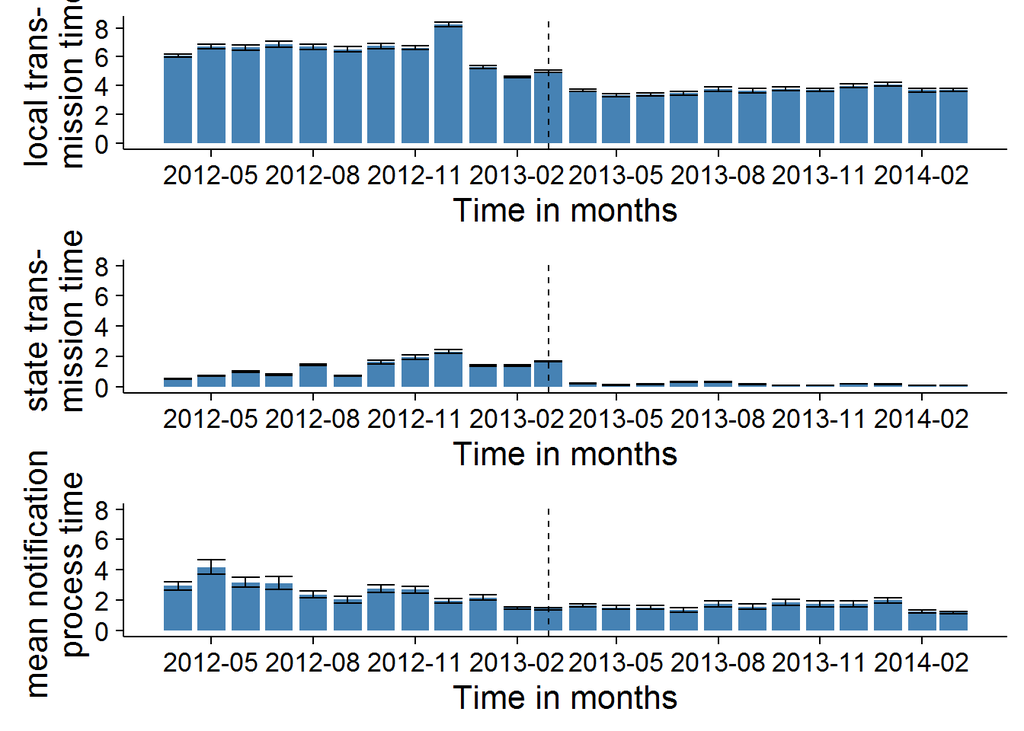

```r
plotNP <- data %>%
  filter(longtermSN3User) %>%
  filter(SoftwareSN2SN3GA=="SN3") %>%
  filter(Yearmonth>=as.Date("2012-04-01")&Yearmonth<as.Date("2014-04-01")) %>%
  group_by(Yearmonth) %>%
  summarise(n=n(),mn=mean(notificationProcessDelay, na.rm=T), sd=sd(notificationProcessDelay, na.rm=T)) %>%
  mutate(se=sd/sqrt(n),LCI=mn+qnorm(0.025)*se,UCI=mn+qnorm(0.975)*se) %>%
  ggplot(aes(x=Yearmonth, y=mn)) +
  geom_bar(stat="identity", fill="steelblue") +
  geom_errorbar(aes(ymax = UCI, ymin=LCI)) +
  theme_classic(base_size = 16) +
  geom_vline(xintercept=as.numeric(as.Date("2013-03-01")), linetype="dashed")+
  scale_x_date(date_break="3 months", date_labels="%Y-%m") +
  scale_y_continuous(limits=c(0,8))+
  labs(x="Time in months", y="mean notification \n process time")

timeplot <- grid.arrange(plotLocal, plotState, plotNP, ncol=1)
```

```r
setEPS()
postscript("../Figures/figure2.eps")
 grid.arrange(plotLocal, plotState, plotNP, ncol=1)
dev.off()
```

png 2

```r
# svg("../Figures/figure2.svg", onefile = TRUE)
#   grid.arrange(plotLocal, plotState, plotNP, ncol=1)
#   dev.off()


# pdf("../Figures/figure2.pdf", width = 10, height = 8) # Open a new pdf file
# grid.arrange(plotLocal, plotState, plotNP, ncol=1)
# dev.off()
```

### Text: Quality and workload of data

|  | gesetz_local | n_total | n_notNA | p | LCI | UCI |
| --- | --- | --- | --- | --- | --- | --- |
| 1 | NachGesetz | 302977 | 53220 | 0.175656898048367 | 0.17430190255888 | 0.177011893537853 |
| 2 | VorGesetz | 362465 | 55334 | 0.152660256852386 | 0.151489370306843 | 0.153831143397928 |

|  | gesetz_local | n_total | n_notNA | p | LCI | UCI |
| --- | --- | --- | --- | --- | --- | --- |
| 1 | NachGesetz | 302977 | 238864 | 0.788389877779501 | 0.786935457304852 | 0.78984429825415 |
| 2 | VorGesetz | 362465 | 288085 | 0.794793980108424 | 0.793479223489469 | 0.79610873672738 |

|  | gesetz_local | n | MeanVersionen | sd | se | LCI | UCI |
| --- | --- | --- | --- | --- | --- | --- | --- |
| 1 | NachGesetz | 302977 | 1.68234882515835 | 1.50171964921789 | 0.00272824917669361 | 1.67700155503118 | 1.68769609528552 |
| 2 | VorGesetz | 362465 | 1.62215386313161 | 1.54465806893487 | 0.00256566127339256 | 1.61712525943923 | 1.62718246682399 |

### Graph 3: Quality and workload

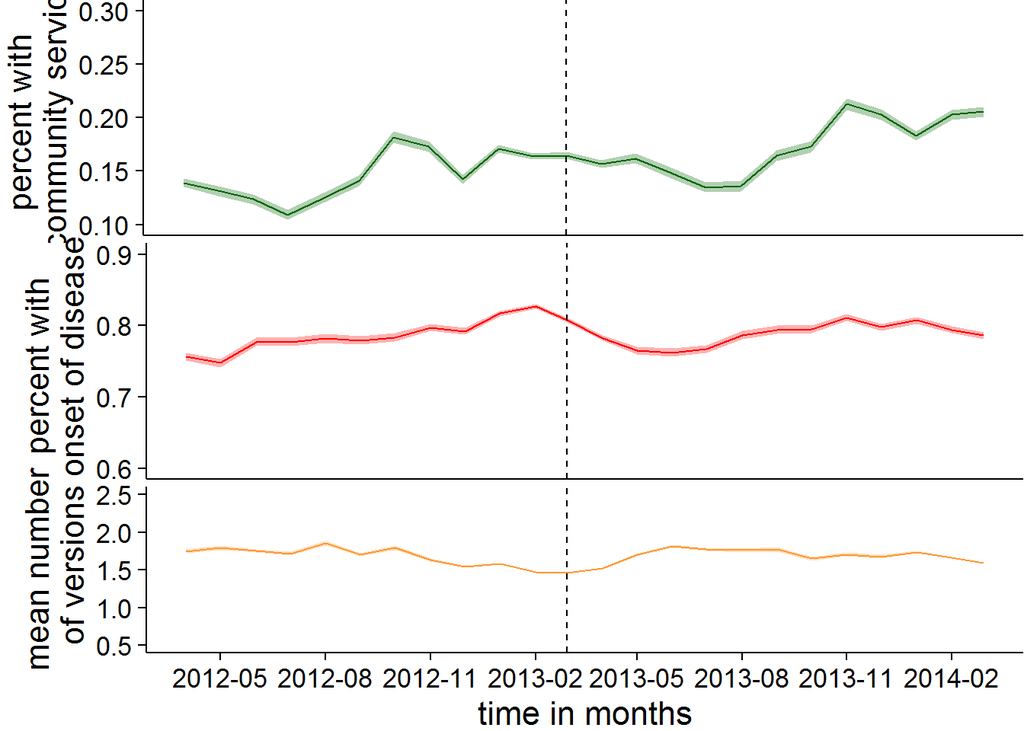

```r
plotCommunity <- data %>%
  filter(Yearmonth>=as.Date("2012-04-01")&Yearmonth<as.Date("2014-04-01")) %>%
  group_by(Yearmonth) %>%
  summarise(n_total=n(), n_notNA = sum(!is.na(Status_33_36_42)), p=n_notNA/n_total) %>%
  mutate(LCI = p - 1.96*sqrt((p*(1-p))/n_total),
         UCI = p + 1.96*sqrt((p*(1-p))/n_total)) %>%
  select(Yearmonth, p, LCI, UCI)  %>%
  ggplot(aes(x=Yearmonth, y=p))  +
  geom_line(stat="identity", color="darkgreen") +
  geom_ribbon(aes(ymin=LCI, ymax=UCI), alpha = 0.3, fill="darkgreen") +
  theme_classic(base_size = 16) +
  theme(legend.position="none",plot.margin=unit(c(0,0,0,0), "mm")) +
  theme(axis.text.x=element_blank(),axis.ticks.x=element_blank(),axis.title.x=element_blank())+
  scale_y_continuous(limits=c(0.1, 0.3)) +
  geom_vline(xintercept=as.numeric(as.Date("2013-03-01")), linetype="dashed")+
  scale_x_date(date_break="3 months", date_labels="%Y-%m") +
  labs(x="Time in months", y="percent with \n community service")

plotOnset <- data %>%
  filter(Yearmonth>=as.Date("2012-04-01")&Yearmonth<as.Date("2014-04-01")) %>%
  group_by(Yearmonth) %>%
  summarise(n_total=n(), n_notNA = sum(!is.na(Erkrankungsbeginn)), p=n_notNA/n_total) %>%
  mutate(LCI = p - 1.96*sqrt((p*(1-p))/n_total),
         UCI = p + 1.96*sqrt((p*(1-p))/n_total)) %>%
  select(Yearmonth, p, LCI, UCI) %>%
  ggplot(aes(x=Yearmonth, y=p))  +
  geom_line(stat="identity", color="red") +
  geom_ribbon(aes(ymin=LCI, ymax=UCI), alpha = 0.3, fill="red") +
  theme_classic(base_size = 16) +
  theme(legend.position="none", plot.margin=unit(c(0,0,0,3), "mm")) +
  theme(axis.text.x=element_blank(),axis.ticks.x=element_blank(),axis.title.x=element_blank())+
  scale_y_continuous(limits=c(0.6, 0.9)) +
  geom_vline(xintercept=as.numeric(as.Date("2013-03-01")), linetype="dashed")+
  scale_x_date(date_break="3 months", date_labels="%Y-%m") +
  labs(x="Time in months", y="percent with \n onset of disease")

PlotMeanAnzahlVersionen <- data %>%
  filter(Yearmonth>=as.Date("2012-04-01")&Yearmonth<as.Date("2014-04-01")) %>%
  group_by(Yearmonth) %>%
  summarise(n=n(), MeanVersionen = mean(VersionNo, na.rm=TRUE), sd=sd(VersionNo, na.rm=T)) %>%
  mutate(se=sd/sqrt(n),LCI=MeanVersionen+qnorm(0.025)*se,UCI=MeanVersionen+qnorm(0.975)*se) %>%
  ggplot(aes(x=Yearmonth, y=MeanVersionen)) +
  geom_line(color="#FF9933") +
  geom_ribbon(aes(ymin=LCI, ymax=UCI), alpha = 0.3, fill="#FF9933") +
  theme_classic(base_size = 16) +
  scale_y_continuous(limits=c(0.5,2.5), name="mean number\n of versions") +
  scale_x_date(date_break="3 months", date_labels="%Y-%m", name="time in months") +
  theme(plot.margin=unit(c(0,0,0,3), "mm"))+
  geom_vline(xintercept=as.numeric(as.Date("2013-03-01")), linetype="dashed")


figure3 <- grid.arrange(plotCommunity, plotOnset, PlotMeanAnzahlVersionen, ncol=1)
```

```r
setEPS()
postscript("../Figures/figure3.eps")
 grid.arrange(plotLocal, plotState, plotNP, ncol=1)
dev.off()
```

png 2

```r
# svg("../Figures/figure3.svg", onefile = TRUE)
#  grid.arrange(plotCommunity, plotOnset, PlotMeanAnzahlVersionen, ncol=1)
#   dev.off()

# pdf("../Figures/figure3.pdf", width = 10, height = 8) # Open a new pdf file
# grid.arrange(plotCommunity, plotOnset, PlotMeanAnzahlVersionen, ncol=1)
# dev.off()
```

### Data not shown: age and sex

```r
datatable(
data %>%
  filter(!is.na(Geschlecht)) %>%
  filter(!is.na(delay_to_transmit_local)) %>%
  group_by(gesetz_local, Geschlecht) %>%
  summarise(
    median=quantile(delay_to_transmit_local, probs = c(0.5), na.rm=TRUE),
    q25 = quantile(delay_to_transmit_local, probs = c(0.25), na.rm=TRUE),
    q75 = quantile(delay_to_transmit_local, probs = c(0.75), na.rm=TRUE),
    n=n()) %>%
  mutate(median = paste0(n, "_", median, " (", q25, " - ", q75,")")) %>%
  select(gesetz_local, Geschlecht, median) %>%
  spread(key=gesetz_local, value=median) %>%
  separate(VorGesetz, into=c("n_before", "median_before"), sep="_") %>%
  separate(NachGesetz, into=c("n_after", "median_after"), sep="_") %>%
  mutate(n_before=as.numeric(n_before)) %>%
  mutate(p_before=round(n_before*100/sum(n_before))) %>%
  mutate(n_before = paste0(n_before, "(", p_before, ")")) %>%
  mutate(n_after=as.numeric(n_after)) %>%
  mutate(p_after=round(n_after*100/sum(n_after))) %>%
  mutate(n_after = paste0(n_after, "(", p_after, ")")) %>%
  select(Variable = Geschlecht, n_before, median_before, n_after, median_after)
)
```

|  | Variable | n_before | median_before | n_after | median_after |
| --- | --- | --- | --- | --- | --- |
| 1 | männlich | 138996(49) | 4 (1 - 7) | 128719(49) | 1 (1 - 4) |
| 2 | weiblich | 144677(51) | 4 (2 - 7) | 134525(51) | 1 (1 - 4) |

```r
datatable(
Univariable_Agegroup <-  data %>%
  filter(!is.na(Agegroup)) %>%
  filter(!is.na(delay_to_transmit_local)) %>%
  group_by(gesetz_local, Agegroup) %>%
  summarise(
    median=quantile(delay_to_transmit_local, probs = c(0.5), na.rm=TRUE),
    q25 = quantile(delay_to_transmit_local, probs = c(0.25), na.rm=TRUE),
    q75 = quantile(delay_to_transmit_local, probs = c(0.75), na.rm=TRUE),
    n=n()) %>%
  mutate(median = paste0(n, "_", median, " (", q25, " - ", q75,")")) %>%
  select(gesetz_local, Agegroup, median) %>%
  spread(key=gesetz_local, value=median) %>%
  separate(VorGesetz, into=c("n_before", "median_before"), sep="_") %>%
  separate(NachGesetz, into=c("n_after", "median_after"), sep="_") %>%
  mutate(n_before=as.numeric(n_before)) %>%
  mutate(p_before=round(n_before*100/sum(n_before))) %>%
  mutate(n_before = paste0(n_before, "(", p_before, ")")) %>%
  mutate(n_after=as.numeric(n_after)) %>%
  mutate(p_after=round(n_after*100/sum(n_after))) %>%
  mutate(n_after = paste0(n_after, "(", p_after, ")")) %>%
  select(Variable = Agegroup, n_before, median_before, n_after, median_after)
)
```

|  | Variable | n_before | median_before | n_after | median_after |
| --- | --- | --- | --- | --- | --- |
| 1 | 0-9 | 76948(27) | 4 (1 - 7) | 66716(25) | 1 (1 - 4) |
| 2 | 10-19 | 21824(8) | 4 (1 - 7) | 17448(7) | 1 (1 - 4) |
| 3 | 20-29 | 26954(9) | 4 (2 - 7) | 28077(11) | 1 (1 - 4) |
| 4 | 30-39 | 24569(9) | 4 (2 - 7) | 23318(9) | 1 (1 - 4) |
| 5 | 40-49 | 29444(10) | 4 (2 - 7) | 24616(9) | 2 (1 - 4) |
| 6 | 50-59 | 28140(10) | 4 (2 - 7) | 25181(10) | 2 (1 - 4) |
| 7 | 60-69 | 19827(7) | 4 (2 - 7) | 19086(7) | 2 (1 - 4) |
| 8 | 70-79 | 26971(9) | 4 (2 - 7) | 27748(11) | 1 (1 - 4) |
| 9 | 80-89 | 23284(8) | 4 (2 - 7) | 24435(9) | 2 (1 - 4) |
| 10 | 90+ | 5990(2) | 4 (2 - 7) | 6884(3) | 2 (1 - 4) |

R version 3.2.2 (2015-08-14) Platform: x86_64-w64-mingw32/x64 (64-bit) Running under: Windows 7 x64 (build 7601) Service Pack 1

locale: [1] LC_COLLATE=German_Germany.1252 LC_CTYPE=German_Germany.1252  
[3] LC_MONETARY=German_Germany.1252 LC_NUMERIC=C  
[5] LC_TIME=German_Germany.1252

attached base packages: [1] grid stats graphics grDevices utils datasets methods  
[8] base

other attached packages: [1] MASS_7.3-43 DT_0.1 svglite_1.0.0  
[4] timeDate_3012.100 gridExtra_2.0.0 knitr_1.11  
[7] scales_0.3.0 ggplot2_2.0.0 tidyr_0.3.1  
[10] dplyr_0.4.3

loaded via a namespace (and not attached): [1] Rcpp_0.12.3 magrittr_1.5 munsell_0.4.2 colorspace_1.2-6 [5] R6_2.1.2 stringr_1.0.0 plyr_1.8.3 tools_3.2.2  
[9] parallel_3.2.2 gtable_0.1.2 DBI_0.3.1 htmltools_0.3  
[13] lazyeval_0.1.10 yaml_2.1.13 assertthat_0.1 digest_0.6.9  
[17] formatR_1.2 htmlwidgets_0.5 evaluate_0.7.2 rmarkdown_0.8  
[21] labeling_0.3 stringi_0.5-5 gdtools_0.0.6 jsonlite_0.9.19